# About

### Logic and Logic Networks

Back to main page

### Navigate

|  | Section | Conponents |  |
| --- | --- | --- | --- |
|  | **Section 1** | Introduction to Numbers and Numbers Systems |  |
|  | **Section 2** | Binary Numbers, Hexadecimal Numbers, Octal Numbers |  |
|  | **Section 3** | Set Theory |  |
|  | **Section 4** | Logic & Logic Networks |  |
|  | **Section 5** | Functions 1: Mathematical Functions |  |
|  | **Section 6** | Functions 2: Invertible Functions |  |
|  | **Section 7** | Functions 3: O-Notation |  |
|  | **Section 8** | Graph Theory |  |
|  | **Section 9** | Trees, Binary Search Trees |  |
|  | **Section 10** | Digraphs and Relation |  |
|  | **Section 11** | Sequences and Series, with Telescoping Series |  |
|  | **Section 12** | Proof by Induction, Convergence and Ratio Tests |  |
|  | **Section 13** | Probability and Counting Problems |  |
|  | **Section 14** | Matrices and Systems of Linear Equations |  |

### Section 4

# Logic

### Propositions

#### Propositions

The negations of a proposition, Compound Statements, Truth tables

- [Logic 2003 Propositions](https://www.youtube.com/watch?v=/YK6tzrBYS14)
- [Logic 2007 Propositions](https://www.youtube.com/watch?v=/SNah7Lai_Lo)

### logical implication

#### logical implication

%- http://whatis.techtarget.com/definition/logical-implication

Logical implication is a type of relationship between two statements or sentences. The relation translates verbally into “logically implies” or “if/then” and is symbolized by a double-lined arrow pointing toward the right ( $\rightarrow$). If A and B represent statements, then $A\rightarrow B$ means “A implies B” or “If A, then B.” The word “implies” is used in the strongest possible sense.

As an example of logical implication, suppose the sentences A and B are assigned as follows:

- A = The sky is overcast.
- B = The sun is not visible.

However, the sense of logical implication is reversed if both statements are negated. That is,

$$(A \rightarrow B) \equiv (-B
\rightarrow -A)$$

- [HERE](https://www.youtube.com/watch?v=/s1f3nCOOzz8)

### Truth Tables

##### Truth Tables

- [Logic: Logical Truth Tables](https://youtube.com/watch?v=/U0tPnYxc0ME)
- [Logic: Introduction to Truth Tables](https://youtube.com/watch?v=/U0tPnYxc0ME)
- [Logic: Proofs using Truth Tables](https://youtube.com/watch?v=/qm-D7yx_Lwo)
- [Logic: Proof with Truth Tables (Worked Example)](https://youtube.com/watch?v=/3dkhjfjUo7M)
- [Logic: Truth Tables - Worked Example 1](https://youtube.com/watch?v=/aQVK6mf4fUw)
- [Logic: Truth Tables - Worked Example 2](https://youtube.com/watch?v=/nn2QdOEeFBU)
- [Logical Proofs -Truth Tables Example](https://youtube.com/watch?v=/pvZrpzLzM60)

#### Older Videos

- [Introduction to Truth Tables](https://www.youtube.com/watch?v=/qLP5fnux3RA)
- [Logic 2007 Question 3 Truth Tables](https://www.youtube.com/watch?v=/U_VxV-3p7dU)
- [Proof using Truth Tables](https://www.youtube.com/watch?v=/qiO6sEmfkIc)
- [Proof using Truth Tables](https://www.youtube.com/watch?v=/Z9YVIP7v-Ik)
- [Logic proof by truth table](https://www.youtube.com/watch?v=/4ZSgi6lmd_4)

# Conditional Connectives

### Conditional Connectives

#### Conditional Connectives

- Truth tables for condition connectives
- The contrapositive
- [Conditional Connectives : p implies q](https://www.youtube.com/watch?v=/FT9ocP-L6Mc)
- [Logic 2001 Implication Connective](https://www.youtube.com/watch?v=/dnem1E71TI4)

# Logic Networks

### Logic Networks

#### AND and OR Gates

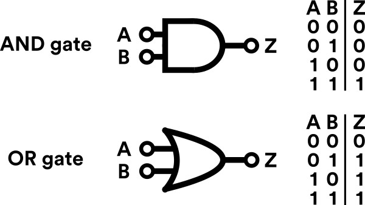

“AND and OR”

#### Logical Operations

- [Logic Networks: (Example 1)](https://www.youtube.com/watch?v=/DtkPULIOlWQ)
- [Logic Networks: (Example 2)](https://www.youtube.com/watch?v=/NzFMJwUR82k)

# Logic - Worksheet 1

### Work Sheet 1

#### Question 2

Let p and q be propositions.

[(i)] Construct the truth table for $p \rightarrow q$. [(ii)] Use truth tables to prove that $\neg q \rightarrow \neg p$ = $p \rightarrow q$.

[(c)] Let $p$, $q$ be the following propositions:

p : this apple is red, q : this apple is ripe.

Express the following statements in words as simply as you can.

[(i)] $p \rightarrow q$ [(ii)] $p \wedge \neg q$.

[output not shown]

#### Exercise

Let $n = \{1, 2,3,4, 5,6,7, 8, 9\}$ and let $p$ and $q$ be the following propositions concerning the integer $n$.

- p: n is even,
- q: $n\geq 5$.

#### Exercise

Let p, q be the following propositions:

$p$ : this apple is red, $q$ : this apple is ripe.

Express the following statements in words as simply as you can:

1. $p \rightarrow q$
2. $p \wedge \neg q$.

Express the following statements symbolically:

3. This apple is neither red nor ripe.
4. If this apple is not red it is not ripe.

#### Question

Let p and q be propositions.

1. Construct the truth table for $p \rightarrow q$.
2. Use truth tables to prove that $\neg q \rightarrow \neg p$ = $p \rightarrow q$.

# Truth Table - Worksheet 2

### Work Sheet 3 - Truth Table Questions

#### {Conditional Connectives}

Construct the truth table for the proposition $p \rightarrow q$.

# Logic Networks - Worksheet 2

### Work Sheet 3 - Logic Networks

#### Question 1

Construct a logic network that accepts as input p and q, which may independently have the value 0 or 1, and gives as final input $\neg(p \wedge \not q)$ (i.e. $\equiv p \rightarrow q$).\

#### Logic Gates

- AND
- OR
- NOT

#### Question 2

Construct a logic network that accepts as input p and q, which may independently have the value 0 or 1, and gives as final input $(p \wedge q) \vee \neg q$ (i.e. $\equiv p \rightarrow q$).

*Important* Label each of the gates appropriately and label the diagram with a symblic expression for the output after each gate.

#### Question 3

Construct a logic network that accepts as input p and q, which may independently have the value 0 or 1, and gives as final input $\neg(p \wedge \not q)$ (i.e. $\equiv p \rightarrow q$).

- Use to prove that the following statements are equivalent to one another.

$$(p \vee q) \wedge \neg q \qquad \equiv
\qquad p\wedge \neg q.$$

Construct a logic network that accepts as input $p$ and $q$, which may independently have the value 0 or 1, and gives as final input $(p \wedge q) \vee \neg q$ (i.e. $\equiv p \rightarrow q$).

*Important* Label each of the gates appropriately and label the diagram with a symblic expression for the output after each gate.